# Star Wars Notebook

#### Load the data file

It’s from [this article](https://fivethirtyeight.com/features/americas-favorite-star-wars-movies-and-least-favorite-characters/) on 538.com

```r
dataset <- read.csv("StarWarsCleaned.csv", header = TRUE)
```

#### Clean the data file

First, we need to add and correct variable names.

To do this, I opened the ‘StarWars.csv’ file in excel and just looked at the correct names. Then I ran this code to see the names in R.

```r
names(dataset)
```

```
 [1] "RespondentID"
 [2] "Have.you.seen.any.of.the.6.films.in.the.Star.Wars.franchise."
 [3] "Do.you.consider.yourself.to.be.a.fan.of.the.Star.Wars.film.franchise."
 [4] "Which.of.the.following.Star.Wars.films.have.you.seen..Please.select.all.that.apply."
 [5] "X"
 [6] "X.1"
 [7] "X.2"
 [8] "X.3"
 [9] "X.4"
[10] "Please.rank.the.Star.Wars.films.in.order.of.preference.with.1.being.your.favorite.film.in.the.franchise.and.6.being.your.least.favorite.film."
[11] "X.5"
[12] "X.6"
[13] "X.7"
[14] "X.8"
[15] "X.9"
```

[output cut: 23 more lines]

Then I changed the names with his command

```r
names(dataset) <- c("RespondentID", "SeenAny", "AreYouAFan", "SeenEp1", "SeenEp2", "SeenEp3", "SeenEp4", "SeenEp5", "SeenEp6", "Ep1Rank","Ep2Rank","Ep3Rank","Ep4Rank","Ep5Rank","Ep6Rank6", "HanAttitude", "LukeAttitude", "LeiaAttitude", "AnakinAttitude", "ObiWanAttitude", "PalpsAttitude", "VaderAttitude", "LandoAttitude", "BobaAttitde","C3POAttitude", "R2D2Attitude", "JarJarAttitude", "PadmeAttitude", "YodaAttitude","WhoShotFirst", "KnowEU", "FanOfEU", "StarTrekFan", "Gender", "Age", "HouseIncome", "Education","Location")
```

Now I can see the new names like this:

```r
names(dataset)
```

```
 [1] "RespondentID"   "SeenAny"        "AreYouAFan"     "SeenEp1"        "SeenEp2"        "SeenEp3"        "SeenEp4"
 [8] "SeenEp5"        "SeenEp6"        "Ep1Rank"        "Ep2Rank"        "Ep3Rank"        "Ep4Rank"        "Ep5Rank"
[15] "Ep6Rank6"       "HanAttitude"    "LukeAttitude"   "LeiaAttitude"   "AnakinAttitude" "ObiWanAttitude" "PalpsAttitude"
[22] "VaderAttitude"  "LandoAttitude"  "BobaAttitde"    "C3POAttitude"   "R2D2Attitude"   "JarJarAttitude" "PadmeAttitude"
[29] "YodaAttitude"   "WhoShotFirst"   "KnowEU"         "FanOfEU"        "StarTrekFan"    "Gender"         "Age"
[36] "HouseIncome"    "Education"      "Location"
```

Let’s visualize a few of the variables.

```r
head(dataset$LandoAttitude)
```

```
[1] Unfamiliar (N/A)
[3] Unfamiliar (N/A)                            Somewhat favorably
[5] Neither favorably nor unfavorably (neutral) Neither favorably nor unfavorably (neutral)
7 Levels:  Neither favorably nor unfavorably (neutral) Somewhat favorably Somewhat unfavorably ... Very unfavorably
```

Two problems pop out.

1. There are Unfamiliar (N/A) values and blank values. We need to remove those.
2. All the values are words. We’d like to work with numbers. We need to recode the values.

The easiest way to work with numbers is to realize that the levels are ordered. They’re just ordered alphabetically instead of according to the ranks we’d like to use. Let’s reorder the levels so that:

1. Very unfavorably
2. Somewhat unfavorably
3. Neither favorably nor unfavorably
4. Somewhat favorably
5. Very favorably
6. Unfamiliar (N/A)
7. “”

```r
dataset$LandoAttitude = factor(dataset$LandoAttitude,levels(dataset$LandoAttitude)[c(7,4,2,3,6,5,1)])
print(levels(dataset$LandoAttitude))
```

```
[1] "Very unfavorably"                            "Somewhat unfavorably"
[3] "Neither favorably nor unfavorably (neutral)" "Somewhat favorably"
[5] "Very favorably"                              "Unfamiliar (N/A)"
[7] ""
```

Now the levels are ordered how we’d like. Now, let’s replace Unfamiliar with NA. NA is the official data missing symbol in R.

```r
dataset$LandoAttitude <- ifelse(dataset$LandoAttitude == "Unfamiliar (N/A)", c(NA), c(dataset$LandoAttitude))
```

If we look at the data, “Unfamiliar (N/A)”" has been replaced with NA. But every other value has been replaced with its number. So all we have to do now, is replace ‘7’ with NA (because “” was reordered to be 7)

```r
dataset$LandoAttitude
```

[output not shown]

```r
dataset$LandoAttitude <- ifelse(dataset$LandoAttitude == 7, c(NA), c(dataset$LandoAttitude))
dataset$LandoAttitude
```

[output not shown]

Perfect!

Now, let’s visualize the data.

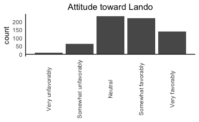

```r
if (!require(ggplot2)){
  install.packages("ggplot2", dependencies = TRUE)
  require(ggplot2)
}
LandoNoNA <- subset (x = dataset, subset = !is.na(LandoAttitude), select = c(LandoAttitude))
ggplot(LandoNoNA, aes(LandoAttitude)) +
  geom_bar() +
  ggtitle ("Attitude toward Lando") +
  theme_minimal() +
  theme(panel.grid = element_blank(),
        axis.line.y = element_line(color="black", size = .5),
        axis.line.x = element_blank(),
        plot.title = element_text(hjust=0.5),
        axis.title.x = element_blank(),
        axis.text.x  = element_text(angle=90, vjust=0.5)) +
  geom_hline(yintercept=0, color="black", size=.5) +
  scale_x_continuous(breaks = c(1,2,3,4,5), labels=c("Very unfavorably","Somewhat unfavorably","Neutral","Somewhat favorably","Very favorably")) +
  coord_cartesian(xlim = c(.5,5.5))
```

Break this down by gender?

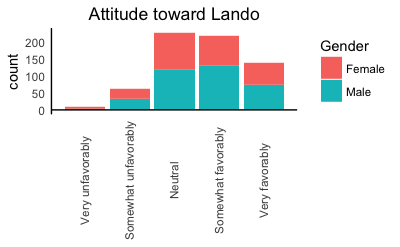

```r
LandoNoNAGender <- subset (x = dataset, subset = !is.na(LandoAttitude) & Gender != "", select = c(LandoAttitude, Gender))
ggplot(LandoNoNAGender, aes(LandoAttitude, group = Gender, fill = Gender)) +
  geom_bar() +
  ggtitle ("Attitude toward Lando") +
  theme_minimal() +
  theme(panel.grid = element_blank(),
        axis.line.y = element_line(color="black", size = .5),
        axis.line.x = element_blank(),
        plot.title = element_text(hjust=0.5),
        axis.title.x = element_blank(),
        axis.text.x  = element_text(angle=90, vjust=0.5)) +
  geom_hline(yintercept=0, color="black", size=.5) +
  scale_x_continuous(breaks = c(1,2,3,4,5), labels=c("Very unfavorably","Somewhat unfavorably","Neutral","Somewhat favorably","Very favorably")) +
  coord_cartesian(xlim = c(.5,5.5))
```

Do men or women like Lando more?

```r
if (!require(plyr)){
  install.packages("plyr", dependencies = TRUE)
  require(plyr)
}
if (!require(effsize)){
  install.packages("effsize", dependencies = TRUE)
  require(effsize)
}
if (!require(reshape2)){
  install.packages("reshape2", dependencies = TRUE)
  require(reshape2)
}
#Setup Variables
IV <-LandoNoNAGender$Gender
DV <-LandoNoNAGender$LandoAttitude
workingDF <- data.frame(IV,DV)
#t-test
tTestOutput = with(workingDF, t.test(DV ~ IV, var.equal = TRUE))
tTestOutput
```

```
    Two Sample t-test

data:  DV by IV
t = -0.51808, df = 655, p-value = 0.6046
alternative hypothesis: true difference in means is not equal to 0
95 percent confidence interval:
 -0.1862150  0.1084655
sample estimates:
mean in group Female   mean in group Male
            3.614865             3.653740
```

```r
#descriptives
tTestSummary <- ddply(workingDF, c("IV"), summarise,
                       N    = sum(!is.na(DV)),
                       mean = mean(DV, na.rm=TRUE),
                       sd   = sd(DV, na.rm=TRUE),
                       se   = sd / sqrt(N)
)
tTestSummary
```

```
      IV   N     mean        sd         se
1 Female 296 3.614865 0.9744092 0.05663638
2   Male 361 3.653740 0.9423927 0.04959962
```

```r
#Effect Size
tTestEffectSize = with(workingDF, effsize::cohen.d(DV ~ IV, hedges.correction=TRUE, na.rm=TRUE))
```

```
Factor with multiple levles, using only the two actually present in data
```

```r
tTestEffectSize
```

```
Hedges's g

g estimate: 0.03978948 (negligible)
95 percent confidence interval:
 inf  sup
-Inf  Inf
```

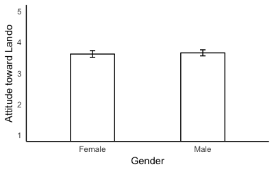

```r
#visualize the data
#Bar Graph
ggplot(workingDF, aes(x = factor(IV), y=DV)) +
  stat_summary(fun.y="mean", geom="bar", width=.4, color="black", fill="white") +
  theme_minimal()  +
  theme(panel.grid = element_blank(), axis.line = element_line(color="black", size = .5)) +
  labs(x = "Gender", y = "Attitude toward Lando")  +
  coord_cartesian(ylim = c(1, 5)) +
  stat_summary(fun.data = "mean_cl_boot", geom="errorbar", width=.05)
```

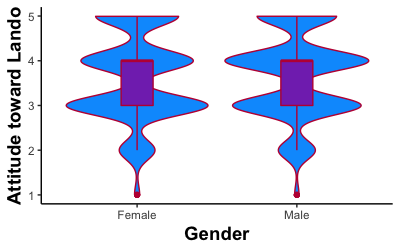

```r
#Violin + Box Plot
workingDF.melt <- melt(workingDF, id.vars=c("IV"))
  ggplot(workingDF.melt, aes(x=factor(IV), y=value)) +
    geom_violin(trim=FALSE, color="#BE1C42", fill="#009CFD") +
    geom_boxplot(width=0.20, color="#BE1C42", fill="#8336BC") +
    theme(panel.background = element_rect(fill = NA), axis.title.y = element_text(face="bold", size=14),axis.title.x = element_text(face="bold", size=14), axis.line = element_line(color="black", size = .5)) +
    labs(x="Gender", y = "Attitude toward Lando") +
    ylim(1,5)
```

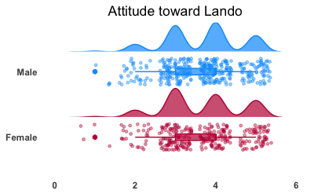

```r
#Raincloud Plots
ggplot(workingDF.melt, aes(x = factor(IV), y = value, fill = factor(IV), color=factor(IV))) +
  geom_violin(position = position_nudge(x = .3), trim = FALSE, alpha=.7) +
  coord_flip(ylim=c(0,6)) +
  theme_minimal() +
  theme(panel.grid = element_blank(), axis.line = element_blank(), legend.position="none", axis.title = element_blank(), axis.text = element_text(face="bold"), plot.title = element_text(hjust=0.5)) +
  annotate("rect", xmin=1.8, xmax=2.3, ymin=0, ymax=6, fill="white", color = "white") +
  annotate("rect", xmin=.8, xmax=1.3, ymin=0, ymax=6, fill="white", color = "white") +
  geom_jitter(aes(y = value, color = factor(IV)), size = 1, alpha = 0.4, width = .2) +
  geom_boxplot(aes(y = value, color = factor(IV)), width= .1, alpha = .7)  +
  scale_fill_manual(values = c("#BE1C42","#009CFD")) +
  scale_color_manual(values = c("#BE1C42","#009CFD")) +
  ggtitle("Attitude toward Lando")
```

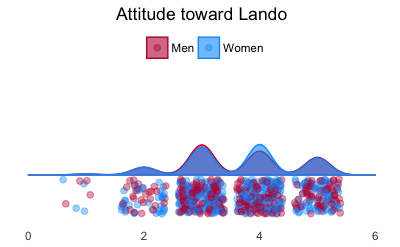

```r
ggplot(workingDF.melt, aes(value)) +
  coord_cartesian(ylim = c(0, 3)) +
  geom_density(aes(fill=factor(IV), color=factor(IV)), alpha = .6, position = position_nudge(y = 1)) +
  geom_jitter (aes(y = .5, color = factor(IV)), size = 2, alpha = .4) +
  theme_minimal() +
  theme(panel.grid = element_blank(), axis.line = element_blank(), legend.position="top", axis.title = element_blank(), axis.text.y = element_blank(),legend.title=element_blank(), plot.title = element_text(hjust=0.5)) +
  scale_fill_manual(values = c("#BE1C42","#009CFD"), labels = c("Men", "Women")) +
  scale_color_manual(values = c("#BE1C42","#009CFD"), labels = c("Men", "Women")) +
  ggtitle("Attitude toward Lando") +
  scale_x_continuous(limits=c(0,6))
```

Now, same thing for Han, C3PO, and R2D2

```r
dataset$HanAttitude = factor(dataset$HanAttitude,levels(dataset$HanAttitude)[c(7,4,2,3,6,5,1)])
dataset$HanAttitude <- ifelse(dataset$HanAttitude == "Unfamiliar (N/A)", c(NA), c(dataset$HanAttitude))
dataset$HanAttitude <- ifelse(dataset$HanAttitude == 7, c(NA), c(dataset$HanAttitude))
dataset$C3POAttitude = factor(dataset$C3POAttitude,levels(dataset$C3POAttitude)[c(7,4,2,3,6,5,1)])
dataset$C3POAttitude <- ifelse(dataset$C3POAttitude == "Unfamiliar (N/A)", c(NA), c(dataset$C3POAttitude))
dataset$C3POAttitude <- ifelse(dataset$C3POAttitude == 7, c(NA), c(dataset$C3POAttitude))
dataset$R2D2Attitude = factor(dataset$R2D2Attitude,levels(dataset$R2D2Attitude)[c(7,4,2,3,6,5,1)])
dataset$R2D2Attitude <- ifelse(dataset$R2D2Attitude == "Unfamiliar (N/A)", c(NA), c(dataset$R2D2Attitude))
dataset$R2D2Attitude <- ifelse(dataset$R2D2Attitude == 7, c(NA), c(dataset$R2D2Attitude))
```

Let’s visualize the correlations

[output not shown]

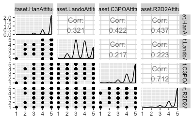

```r
if (!require(GGally)){
  install.packages("GGally", dependencies = TRUE)
  require(GGally)
}
heroDF <- data.frame(dataset$HanAttitude, dataset$LandoAttitude, dataset$C3POAttitude, dataset$R2D2Attitude)
ggpairs(heroDF)
```

```r
if (!require(psych)){
  install.packages("psych", dependencies = TRUE)
  require(psych)
}
myCorrtest <- corr.test(x=heroDF, y = NULL, use = "pairwise",method="spearman",adjust="holm", alpha=.05,ci=TRUE)
myCorrtest
```

```
Call:corr.test(x = heroDF, y = NULL, use = "pairwise", method = "spearman",
    adjust = "holm", alpha = 0.05, ci = TRUE)
Correlation matrix
                      dataset.HanAttitude dataset.LandoAttitude dataset.C3POAttitude dataset.R2D2Attitude
dataset.HanAttitude                  1.00                  0.32                 0.39                 0.38
dataset.LandoAttitude                0.32                  1.00                 0.21                 0.22
dataset.C3POAttitude                 0.39                  0.21                 1.00                 0.74
dataset.R2D2Attitude                 0.38                  0.22                 0.74                 1.00
Sample Size
                      dataset.HanAttitude dataset.LandoAttitude dataset.C3POAttitude dataset.R2D2Attitude
dataset.HanAttitude                   814                   670                  801                  808
dataset.LandoAttitude                 670                   672                  666                  671
dataset.C3POAttitude                  801                   666                  812                  810
dataset.R2D2Attitude                  808                   671                  810                  820
Probability values (Entries above the diagonal are adjusted for multiple tests.)
                      dataset.HanAttitude dataset.LandoAttitude dataset.C3POAttitude dataset.R2D2Attitude
dataset.HanAttitude                     0                     0                    0                    0
dataset.LandoAttitude                   0                     0                    0                    0
dataset.C3POAttitude                    0                     0                    0                    0
dataset.R2D2Attitude                    0                     0                    0                    0

 To see confidence intervals of the correlations, print with the short=FALSE option
```

Let’s see who is more popular: Human duo vs. Robot duo

First, create composite variables.

```r
#Han, Lando composite variable
HanLando <- data.frame (dataset$HanAttitude, dataset$LandoAttitude)
HanLando.keys <- make.keys(HanLando, list(HanLando=c(1,2)))
HanLando.scales <- scoreItems (HanLando.keys, HanLando)
HanLando.scores <- HanLando.scales$scores
dataset$HanLando <- HanLando.scores[,]
HanLando.scales$alpha
```

```
       HanLando
alpha 0.4569763
```

```r
#Han, Lando composite variable
C3R2 <- data.frame (dataset$C3POAttitude, dataset$R2D2Attitude)
C3R2.keys <- make.keys(C3R2, list(C3R2=c(1,2)))
C3R2.scales <- scoreItems (C3R2.keys, C3R2)
C3R2.scores <- C3R2.scales$scores
dataset$C3R2 <- C3R2.scores[,]
C3R2.scales$alpha
```

```
           C3R2
alpha 0.8397589
```

Visualize the new variables

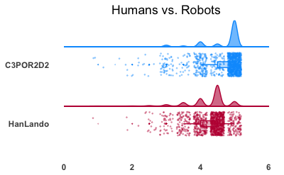

```r
#Melt the variables
humansvsrobots <- data.frame(dataset$HanLando, dataset$C3R2)
names(humansvsrobots) <- c("HanLando", "C3POR2D2")
humansvsrobots.melt <- melt(humansvsrobots)
ggplot(humansvsrobots.melt, aes(x = variable, y = value, group=variable, fill=variable, color=variable)) +
  geom_violin(position = position_nudge(x = .3), trim=FALSE, alpha=.6) +
  coord_flip() +
  theme_minimal() +
  theme(panel.grid = element_blank(), axis.line = element_blank(), legend.position="none", axis.title.y = element_blank(), axis.text = element_text(face="bold"), axis.title = element_blank(), plot.title = element_text(hjust=0.5)) +
  annotate("rect", xmin=1.8, xmax=2.3, ymin=0, ymax=6, fill="white", color = "white") +
  annotate("rect", xmin=.8, xmax=1.3, ymin=0, ymax=6, fill="white", color = "white") +
  geom_jitter(aes(y = value, color = variable), size = .25, alpha = 0.3, width = .2) +
  geom_boxplot(aes(y = value, color = variable), width= .1, alpha = .3, outlier.size = 0) +
  scale_fill_manual(values = c("#BE1C42","#009CFD")) +
  scale_color_manual(values = c("#BE1C42", "#009CFD")) +
  ggtitle("Humans vs. Robots") +
  geom_segment (aes(x = 2.3, y = 0, xend = 2.3, yend = 6, color="C3POR2D2"), size=.3) +
  geom_segment (aes(x = 1.3, y = 0, xend = 1.3, yend = 6, color="HanLando"), size=.3)
```

*t*-test

```r
workingDF <- data.frame(dataset$HanLando, dataset$C3R2)
#t-test
tTestOutput = with(dataset, t.test(dataset$HanLando, dataset$C3R2, paired = TRUE))
tTestOutput
```

```
    Paired t-test

data:  dataset$HanLando and dataset$C3R2
t = -20.06, df = 1185, p-value < 2.2e-16
alternative hypothesis: true difference in means is not equal to 0
95 percent confidence interval:
 -0.3980236 -0.3271029
sample estimates:
mean of the differences
             -0.3625632
```

```r
mean(dataset$HanLando)
```

```
[1] 4.28457
```

```r
sd(dataset$HanLando)
```

```
[1] 0.524672
```

```r
mean(dataset$C3R2)
```

```
[1] 4.647133
```

```r
sd(dataset$C3R2)
```

```
[1] 0.6496187
```

```r
#Effect Size
tTestEffectSize = effsize::cohen.d(dataset$HanLando, dataset$C3R2, paired=TRUE, na.rm=TRUE, hedges.correction=TRUE)
tTestEffectSize
```

```
Hedges's g

g estimate: -0.5823081 (medium)
95 percent confidence interval:
       inf        sup
-0.6645242 -0.5000921
```

[figure not shown]

```r
ggplot(humansvsrobots.melt, aes(x = factor(variable), y=value)) +
  stat_summary(fun.y="mean", geom="bar", width=.4, color="black", fill="white") +
  theme_minimal() +
  theme(panel.grid = element_blank(), axis.line.y = element_line(color="black", size = .5)) +
  geom_hline(yintercept=0, color="black", size=.5) +
  labs(x = "Humans vs Robots", y = "Attitudes") +
  stat_summary(fun.data = "mean_cl_boot", geom="errorbar", width=.05)
```

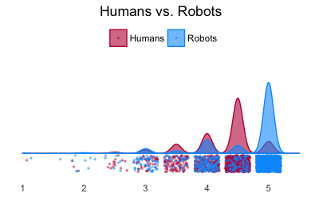

```r
ggplot(humansvsrobots.melt, aes(value)) +
  coord_cartesian(ylim = c(0, 5)) +
  geom_density(aes(fill=factor(variable), color=factor(variable)), alpha = .6, position = position_nudge(y = 1)) +
  geom_jitter (aes(y = .5, color = factor(variable)), size = .5, alpha = .4) +
  theme_minimal() +
  theme(panel.grid = element_blank(), axis.line = element_blank(), legend.position="top", axis.title = element_blank(), axis.text.y = element_blank(),legend.title=element_blank(), plot.title = element_text(hjust=0.5)) +
  scale_fill_manual(values = c("#BE1C42","#009CFD"), labels = c("Humans", "Robots")) +
  scale_color_manual(values = c("#BE1C42","#009CFD"), labels = c("Humans", "Robots")) +
  ggtitle("Humans vs. Robots") +
  scale_x_continuous(limits=c(1,5.5))
```

One last thing. Plotting just one correlation with pretty colors:

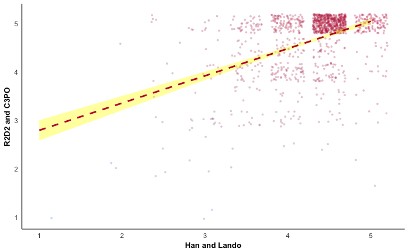

```r
dataset$pc <- predict(prcomp(~dataset$HanLando+dataset$C3R2, dataset))[,1]
ggplot(dataset, aes(dataset$HanLando,
                    dataset$C3R2,
                    color = pc)) +
  geom_jitter(shape = 16,
              size = 1,
              show.legend = FALSE,
              alpha = .3) +
  geom_smooth(method=lm,
              color="#BE1C42",
              fill="yellow",
              linetype="dashed") +
  theme_minimal() +
  scale_color_gradient(low = "#BE1C42",
                       high = "#009CFD") +
  labs(x = "Han and Lando",
       y = "R2D2 and C3PO") +
  theme (axis.title.y = element_text(face="bold", size=10),
         axis.title.x = element_text(face="bold", size=10),
         panel.grid = element_blank(),
         axis.line = element_line(color="black", size = .5))
```